# Frontiers: A Simple Forward Difference-in-Differences Method

Converted from PDF `Li-ForwardDifferenceInDifferences-2024-MKSC.pdf` · 14 pages · anchors: page `#pN`, block `#pN-bK`

Page 1

### **Frontiers: A Simple Forward Difference-in-Differences Method**

#### **Kathleen T. Li<sup>a</sup>**

**a**McCombs School of Business, University of Texas at Austin, Austin, Texas 78712 **Contact:** kathleen.li@mccombs.utexas.edu, https://orcid.org/0000-0002-7813-3626 (KTL)

[figure not shown]

NOTE: complex table shown as an image of the PDF; the text below is a rough machine extraction and may be mis-aligned.

**1. Introduction** Marketing researchers are interested in establishing causal effects in a variety of contexts (Busse et al. 2006, Goldfarb and Tucker 2011, Puranam et al. 2017, Guo et al. 2020, Berman and Israeli 2022). The difference-in- differences (DID) method is the most popular method to estimate treatment effects, such as the average treatment effect (ATE) and the average treatment effect on the trea ted (ATT), when using quasiexperimental data. DID is simple, easy to implement, and widely applicable. In fact, it even applies to data with only two time periods (one pretreatment period and one posttreatment period) and any number of treatment and control units. Market ing scholars have used DID to study how television advertising influences online shopping (Liaukonyte et al. 2015), how showroom openings affect sales (Bell et al. 2018), and the impact of a tax on sweetened beverages (Seiler et al. 2021) among many others (Mantin and Rubin 2016, Calzada and Gil 2020, Johnson et al. 2020, Todri 2022, Wang et al. 2022, Li and Van den Bulte 2023).

However, DID has a restrictive identifying assump tion that may not be met in many data settings. The DID parallel trends assumption states that the

treatment unit’s outcomes would have been parallel to the average of the control units’ outcomes during the posttreatment periods in the absence of treatment. Because this assumption is a statement about a counter factual outcome of what the treatment outcomes would have been without treatment, it cannot be checked empirically. Therefore, a common practice is to check whether the parallel trends assumption holds during the pretreatment periods (which we call parallel pretrends assumption). Having parallel pretrends together with the assumption that the correlation between the treat ment and control units’ outcomes is stable during the posttreatment periods in the absence of treatment identi fies the treatment effect (e.g., ATT). Therefore, selecting the most relevant control units so that the DID parallel pretrends assumption is likely to hold is of utmost importance. When selection into treatment is based on some observables, various covariate-matching methods, such as propensity score or *K*-nearest-neighbor match ing, can be used to select the control units. When selec tion is based on unobservables, the extant literature does not offer a satisfying solution for how to select control units for the DID method.

Page 2

However, there have been many recent developments expanding the causal inference tool kit beyond DID for marketers to include more flexible estimators, although they require long time series. Perhaps the most popular alternative approach is the synthetic control (SC) method proposed by Abadie and Gardeazabal (2003) and Abadie et al. (2010). The SC method relaxes the DID equal weight assumption and uses a weighted average of con trols to estimate the treatment unit’s counterfactual out comes. Allowing for flexible weights can better handle heterogeneity between treatment and control units. The SC method has been used to estimate the effect of TV advertising on online chatter (Tirunillai and Tellis 2017) and the effect of banning foreign pharmacies from spon sored search (Chesnes et al. 2017). Another method pro posed by Hsiao et al. (2012), which we will refer to as the HCW method, is an even more flexible method that imposes no constraints on the weights for controls units. However, these flexible methods also have limitations. First, the inference theory for the synthetic control method and HCW methods do not exist under certain data settings (e.g., nonstationary data where the struc ture of nonstationary is unknown). Second, the HCW method is not feasible when the number of control units is greater than the number of pretreatment time periods and likely suffers from overfitting.

Recently, Shi and Huang (2023) proposed the For ward HCW (FHCW) method, which uses a forward selection algorithm to select an appropriate subset of control units and then, applies the HCW method. For ward selection is an iterative algorithm that chooses a relevant subset of control units. It proceeds by first choosing the best subset of size 1. Then, it chooses the best subset of size 2 that includes the first subset. The algorithm continues to choose greater subsets that have one more control unit than the previous subset in the same way. Forward HCW can be applied even when HCW breaks down but has several limitations. First, similar to the synthetic control and HCW methods, there is no inference theory for nonstationary data of unknown structure, which is a key drawback as mar keting data often fall into this category. Second, For ward HCW may still suffer from overfitting if it selects a large number of control units, and it is infeasible when the number of selected control units is larger than the number of pretreatment time periods.

We propose a simple forward difference-in-differences (Forward DID) method that takes advantage of the for ward selection algorithm to select a relevant subset of control units and avoids the overfitting problem of the Forward HCW method. Forward DID flexibly selects the appropriate control units and therefore, is more likely able to accurately estimate the counterfactual and ATT than the DID method. Forward DID has several advan tages. First, as a flexible alternative to DID, Forward DID can be widely applied and suitable even when DID is too

restrictive. Second, Forward DID can accommodate any number of control units. Third, there are no overfitting concerns because Forward DID only needs to estimate one parameter after identifying a subset of control units using the forward selection algorithm. Fourth, by using a greedy algorithm that is a myopic approximation of an optimal algorithm, the Forward DID has computational advantages over algorithms that consider all possible subsets of control units. Fifth, we develop the inference theory, which is applicable to both stationary and non stationary data. Finally, we establish the consistency of the Forward DID method. We compare the performance of the Forward DID method with alternative methods using simulations and an empirical application to store openings.<sup>1</sup>

**2. Forward Difference-in-Differences Method 2.1. Notation** We first present the notation used for the DID method, which we will build upon for the Forward DID method. We consider the case of one treatment unit and *N* control units and extend to multiple treatment units in Online Appendix C. Let N *co* denote the subset of control units that is used to estimate the ATT by the DID method, and let *Nco* denote the number of control units in N *co*.<sup>2</sup> The total number of time periods is *T*, so *t*  1,*:::*,*T*. The out come of the treatment unit at time *t* is *ytr*,*t*, and the out come of the *i*th control unit at time *t* is *yit* for *i*  1,*:::*,*N*. The treatment unit receives a treatment at time *T*1 + 1 (1 *< T*1 *< T*), and the *N* units that do not receive any treatment serve as potential control units.

*tr*,*t* <sup>to denote the outcomes of the treat</sup> ment unit with and without treatment, respectively. We use *ytr*,*t* without superscript to denote the observed out come of the treatment unit at time *t*. Therefore, the treat ment effect at time *t* for *t > T*1 is *y*<sup>1</sup>

*tr*,*t* because *y*<sup>1</sup>

**equation / math rendering (image)**

NOTE: contains mathematical notation; text above is the PDF text layer and symbols may be mis-extracted. Image shows the original.

**equation / math rendering (image)**

NOTE: contains mathematical notation; text above is the PDF text layer and symbols may be mis-extracted. Image shows the original.

*tr*,*t*<sup>)</sup>*<sup>:</sup>* (2.1)

Because we only have one treatment unit, the average is over the number of posttreatment periods, *T*2.

Because the counterfactual *y*<sup>0</sup>

*tr*,*t* <sup>for</sup>*<sup>t</sup><sup>></sup><sup>T</sup>*<sup>1</sup><sup>is not observ</sup> able, we need to estimate *y*<sup>0</sup>

**equation / math rendering (image)**

NOTE: contains mathematical notation; text above is the PDF text layer and symbols may be mis-extracted. Image shows the original.

where α is an unknown parameter (the intercept) and *vt* is a zero mean, stationary idiosyncratic error term.<sup>3</sup>

Page 3

We allow *y*<sup>0</sup>

*tr*,*t* <sup>and</sup>*<sup>y</sup>*N *co*,*t* <sup>to be nonstationary processes</sup> (e.g., nonlinear trend processes) of unknown structure provided *vt* has zero mean and a central limit theorem applies to its partial sum. Model (2.2) implies that the DID parallel trends assumption holds as the possible nonlinear trending components cancel from *y*<sup>0</sup>

*tr*,*t* <sup>and</sup> *y*N *co*,*t*, rendering the difference between the two pro cesses a trendless stationary process. As we will show, model (2.2) identifies ATT and allows us to consistently estimate the ATT.

The ATT estimate can be obtained by first estimating model (2.2) using the pretreatment data

*ytr*, *t y*N *co*, *t*  α + *vt*, *t*  1, *: : :* , *T*1*:* (2.3)

We use the least squares method to estimate α:

**equation / math rendering (image)**

NOTE: contains mathematical notation; text above is the PDF text layer and symbols may be mis-extracted. Image shows the original.

**equation / math rendering (image)**

NOTE: contains mathematical notation; text above is the PDF text layer and symbols may be mis-extracted. Image shows the original.

(*ytr*, *t y*N *co*, *t*)*:* (2.4)

Therefore, the estimated in-sample fitted value (for *t* ≤*T*1) and the out-of-sample predicted counterfactual (for *t > T*1) are

The estimated treatment effect at time *t* (with *t > T*1) is *ytr*,*t* ˆ*y*<sup>0</sup>

*tr*,*t*<sup>. Therefore, the ATT is estimated by</sup>

**equation / math rendering (image)**

NOTE: contains mathematical notation; text above is the PDF text layer and symbols may be mis-extracted. Image shows the original.

**equation / math rendering (image)**

NOTE: contains mathematical notation; text above is the PDF text layer and symbols may be mis-extracted. Image shows the original.

**equation / math rendering (image)**

NOTE: contains mathematical notation; text above is the PDF text layer and symbols may be mis-extracted. Image shows the original.

(*ytr*,*t* ˆ*y*<sup>0</sup>

*tr*,*t*<sup>)</sup>*<sup>:</sup>* (2.6)

The advantage of considering a regression-based ATT estimate is that it allows us to easily analyze the qual ity of the fit by examining the goodness-of-fit *R*<sup>2</sup>of the regression model (2.3):

**equation / math rendering (image)**

NOTE: contains mathematical notation; text above is the PDF text layer and symbols may be mis-extracted. Image shows the original.

**equation / math rendering (image)**

NOTE: contains mathematical notation; text above is the PDF text layer and symbols may be mis-extracted. Image shows the original.

where ˆ*v*N *co*,*t*  *ytr*,*t y*N *co*,*t* ˆαN *co* is the estimated resid

*t*1 *<sup>y</sup><sup>tr</sup>*<sup>,</sup>*<sup>t</sup>*<sup>is the average of</sup> the treatment unit’s outcome over the pretreatment period. We explicitly include N *co* as a subscript in *R*<sup>2</sup>to emphasize that the quality of the fit depends on the subset of selected control units, N *co*. We turn to the problem of how to the select control units next in Sec tion 2.2.

**2.2. Forward Difference-in-Differences Algorithm** When using DID to estimate the treatment effect (e.g., ATT), researchers need to decide which control units to choose from the potential control units. Deciding how to select relevant control units is a challenging and impor tant problem. When selection is based on observables, various covariate-matching methods have been pro posed in the literature. See Abadie (2021) for a survey of

various matching methods. The assumption behind the covariate-matching method is that when covariates of a control unit and a treatment unit are close to each other, then it is likely that their outcomes are parallel in the absence of treatment. However, this assumption can fail in practice. The similarity of outcomes may depend on some unobserved latent factors, and therefore, matching based on observed covariates may not be enough to ensure that DID can be used.

We propose a simple Forward DID method that first uses a forward selection algorithm to select a relevant subset of control units and then applies the DID method. Forward DID flexibly selects the appropriate control units and therefore, is more likely able to accu rately estimate the counterfactual and ATT than the DID method. Next, we outline the steps of the Forward DID method.

Step 1. Select one control unit. Without loss of gener ality, choose the *i*th unit from the control pool. We then estimate ATT using Equations (2.3)–(2.7) but replace *y*N *co*,*t* with *yit* (*Nco*1 in this initial step). Do this for each of the *N* control units (*i*  1,*:::*,*N*) to create *N* one- control-unit DID models. Choose the model with the highest *R*<sup>2</sup>

*t*1<sup>(</sup>*<sup>y</sup><sup>tr</sup>*<sup>,</sup>*<sup>t</sup> <sup>y</sup><sup>it</sup>*<sup>)</sup><sup>.</sup> Therefore, this first step selects one submodel with *Nco*1.

Step 2. After selecting the first control unit using Step 1, choose another (the second) control unit from the remaining *N* – 1 control pool. Do this one at a time, and add it to the one-control-unit model selected in Step 1. This results in *N* – 1 two-control-unit models. Choose the model with the highest *R*<sup>2</sup>among these *N* – 1 two-control-unit models.

Step 3. Continue the process by adding one more control unit, one at a time, to the previously selected model. At the end, we obtain a model containing all the *N* control units and therefore, have *N* selected submo dels. The first one has one control unit, the second one has two control units, … , and the last one has *N* con trol units. Choose the model with the highest *R*<sup>2</sup>value from these *N* models. This is the model that the For ward DID method uses to estimate the ATT. We use c N *co* to denote the subset of controls selected by the For ward DID method.

Note that there is no concern of overfitting no matter how large *Nco* is as all models only contain a single unknown parameter α. Unlike a conventional regression model, all these submodels contain only one parameter α, and therefore, *R*<sup>2</sup>is identical to the adjusted *R*<sup>2</sup>. The forward selection algorithm is a myopic approximation of the algorithm that would optimally sequence control units. However, allowing some degree of suboptimally buys us computational efficiency. This is especially important when the number of control units, *N*, is large and the optimal algorithm becomes intractable. Forward

Page 4

DID is a viable and valuable alternative. To illustrate this, consider a setting similar to our empirical applica tion with a pool of *n*  60 control units. Forward DID only evaluates 1 + 2 + *:::* + 60  1,830 submodels as opposed to 2<sup>60</sup> *>* 1*:*15 × 10<sup>18</sup>for the optimal algorithm.

We would like to mention related recent literature on detecting latent group structure in panel data mod els (Bonhomme and Manresa 2015, Ando and Bai 2016, Su et al. 2016). It may be possible to use this approach to select control units whose sample path is likely to be parallel with the treatment unit. Specifically, assuming that a heterogeneous panel consists of a few homoge neous, latent subgroups, this recent literature can be used to detect and assign each control unit to a group. Then, in a similar spirit to the Forward DID method, the subgroup of control units with the highest correla tion to the treatment unit during the pretreatment period is most likely to satisfy the parallel pretrends assumption and can be used to estimate a causal effect. However, theoretically justifying such an approach is beyond the scope of the current paper.

**2.3. Inference Theory of the Forward DID Method** In this section, we present the identifying assumption of the Forward DID method before presenting the inference theory.

**Assumption 2.1.** *The subset of control units selected by the*

**equation / math rendering (image)**

NOTE: contains mathematical notation; text above is the PDF text layer and symbols may be mis-extracted. Image shows the original.

*i*∈<sup>ˆ</sup>N *co<sup>y</sup><sup>it</sup>*<sup>,</sup>

b*Nco is the number of control units in* c N *co*, *and vt is a weakly dependent process with zero mean and finite variance*.

Assumption 2.1 implies that the correlation between *y*<sup>0</sup>

*tr*,*t* <sup>and</sup>*<sup>y</sup>* <sup>ˆ</sup>N *co*,*t* <sup>is stable during the pretreatment and post</sup> treatment periods in the absence of treatment. Assump tion 2.1 is a Forward DID version of the parallel trends assumption, which we need to consistently estimate the ATT. Assumption 2.1 allows for *y*<sup>0</sup>

*tr*,*t* <sup>and</sup>*<sup>y</sup>* <sup>ˆ</sup>N *co*,*t* <sup>to be non</sup> stationary processes of unknown form provided that the difference of the two processes is a stationary process. To better understand this assumption, we describe a situa tion where this assumption is violated. If an intercept- adjusted treatment unit is outside the range of the control units (e.g., the treatment’s outcome has an upward trend that is steeper than that of all the control units’ out comes), then this assumption will be violated because no subset of control units can trace the steeper upward trend of the treatment unit. In such a case, the Forward DID method should not be applied, and researchers should consider alternative methods, such as factor model- based methods, modified synthetic control methods, or the augmented difference-in-differences method, which allow the treatment unit to be outside the range of the control units (Bai 2003, Doudchenko and Imbens 2016,

Xu 2017, Li 2020, Bai and Ng 2021, Li and Sonnier 2023, Li and Van den Bulte 2023).

Next, we present the inference theory for the For ward DID method in the following proposition.

**Proposition 2.1.** *Under Assumption* 2.1 *and Assump tions* 2–4 *in Online Appendix A*, *as T*1, *T*2 →∞,

[output not shown]

**equation / math rendering (image)**

NOTE: contains mathematical notation; text above is the PDF text layer and symbols may be mis-extracted. Image shows the original.

**equation / math rendering (image)**

NOTE: contains mathematical notation; text above is the PDF text layer and symbols may be mis-extracted. Image shows the original.

**equation / math rendering (image)**

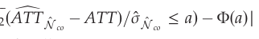

NOTE: contains mathematical notation; text above is the PDF text layer and symbols may be mis-extracted. Image shows the original.

→0 *for all a* ∈R, (2.8)

**equation / math rendering (image)**

NOTE: contains mathematical notation; text above is the PDF text layer and symbols may be mis-extracted. Image shows the original.

*and* Φ(·) *is the standard normal cumulative distribution function*.

The proof of Proposition 2.1 is in Online Appendix B. Our inference theory for the Forward DID method accommodates both stationary and nonstationary data of known and unknown structure. In addition, it is sim ple and straightforward to apply as it is based on normal inference theory. In fact, the availability of widely appli cable inference theory for the Forward DID method is one of its major advantages compared with other flexible alternatives to the DID method, such as the synthetic control method, the synthetic control method with an intercept, the HCW method, and the Forward HCW method. There is no inference theory for the synthetic control method (with and without an intercept), the HCW method, and the Forward HCW method when the data are nonstationary of unknown structure. Unlike the synthetic control method (with and without an inter cept), which uses a weighted average of control units, or the HCW and Forward HCW methods, which use a lin ear combination of the control units, the Forward DID method, like DID, uses a simple, unweighted average of the control units and therefore, avoids estimating a large number of parameters. It is this simplicity that lends itself to straightforward inference theory. In the appen dix, we present a practitioner’s guide outlining the steps of using the Forward DID method to estimate the ATT and conduct inference.

To examine the finite sample performance, we use simulations to compare the Forward DID method with alternative methods (DID, SC, synthetic control with an intercept (*SCI*), and Forward HCW).<sup>4</sup> The full simu lation results are in Online Appendix E. We find that the Forward HCW method likely overfits, resulting in large mean square errors (MSEs) for all cases. For data-generating processes (DGPs) where DID is appli cable, DID and SC methods perform best as expected, although Forward DID still performs well. For DGPs where DID is not applicable, Forward DID and the synthetic control method with an intercept (Abadie and L’hour 2021) perform best, with the Forward DID outperforming the synthetic control method with an

Page 5

intercept when the pre- and posttreatment periods are shorter.

**2.4. Consistency of the Forward DID Method** In this section, we establish consistency of the Forward DID method. We interchangeably use consistency of the Forward DID method and consistency of the forward selection algorithm used by the Forward DID method. We can see from (2.7) that selecting a submodel with the largest *R*<sup>2</sup>is equivalent to selecting a model with the smallest sum of squared residuals (*SSR*  <sup>P</sup>*<sup>T</sup>*<sup>1</sup>

*t*1 <sup>ˆ</sup>*<sup>v</sup>*<sup>2</sup>

N *co*,*t*<sup>. Therefore, we can reinterpret</sup> the forward selection algorithm (used by the Forward DID method) as minimizing the empirical variance in each step (as it is equivalent to maximizing *R*<sup>2</sup>).

**Proposition 2.2.** *Assume that the theoretical forward selection algorithm only selects a single subset*, N <sup>∗</sup>

*co*<sup>,</sup>*<sup>and N</sup> is a fixed positive integer*. *Then*, *under Assumption* 2.1 *and Assumptions* 2–4 *in Online Appendix A*,

**equation / math rendering (image)**

NOTE: contains mathematical notation; text above is the PDF text layer and symbols may be mis-extracted. Image shows the original.

**equation / math rendering (image)**

NOTE: contains mathematical notation; text above is the PDF text layer and symbols may be mis-extracted. Image shows the original.

The proof of Proposition 2.2 is in Online Appendix D. Proposition 2.2 shows that when *N* is fixed and the the oretical forward selection algorithm selects a single subset N <sup>∗</sup>

*co*<sup>, then with probability approaching one (as</sup> *T*1 increases), our forward selection algorithm used by the Forward DID method will select the same subset as the infeasible theoretical forward selection algorithm. That is, the Forward DID method can consistently select the relevant subset of control units.

The final set selected by the theoretical forward selec tion algorithm may not be a singleton because there may be ties during the selection process. Establishing consistency while allowing for ties requires more com plicated notation and more sophisticated proofs, which we deal with in Proposition D.1 in Online Appendix D.

In Online Appendix D, we also relax the fixed *N* assumption and prove consistency for the case that allows *N* to increase with *T*1 (Proposition D.2 in Online Appendix D). Therefore, the consistency results pre sented in Proposition 2.2 and Online Appendix D (Pro positions D.1 and D.2) are one of the main theoretical contributions of the paper in addition to the inference the ory presented in Section 2.3, and it grounds the Forward DID method with another good theoretical property.

**3. Store Opening on Sales** Changing consumer needs have made it imperative for online retailers to identify factors that are critical for its growth. We study an online-first retailer that sells men’s clothing and accessories. When the retailer launched in 2007, it started completely online and later opened brick-and-mortar stores in certain cities so that custo mers could touch and try the products before deciding to purchase. However, given the high cost of opening a physical store, it is important to accurately assess the benefit or the additional increase in sales because of the store opening.

**3.1. ATTs and Confidence Intervals** A necessary condition for a method to be applicable is that the sales estimated by that method need to fit the actual sales well in the pretreatment period. To check this, we plot the sales in Atlanta, San Diego, and San Jose along with the estimated in-sample fit/counterfactual using Forward DID and alternative methods in Figures 1–3. In each of the three figures, the solid lines are the actual sales, and the dashed lines are the in-sample fit in the pre treatment period (*t* ≤*T*1) and the out-of-sample pre dicted counterfactual sales in the posttreatment period (*t > T*1). For instance, for the Forward DID method, the

Page 6

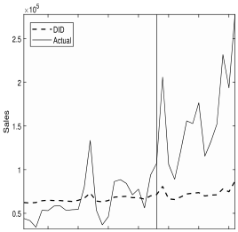

NOTE: figure/graphic rendered as an image from the PDF; its content is not machine-readable text. Caption (if any) follows as the next block.

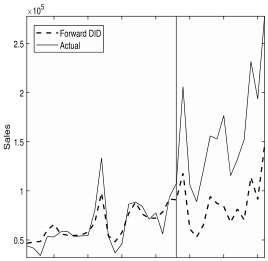

NOTE: figure/graphic rendered as an image from the PDF; its content is not machine-readable text. Caption (if any) follows as the next block.

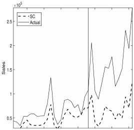

NOTE: figure/graphic rendered as an image from the PDF; its content is not machine-readable text. Caption (if any) follows as the next block.

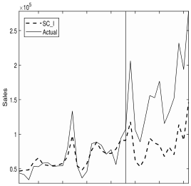

NOTE: figure/graphic rendered as an image from the PDF; its content is not machine-readable text. Caption (if any) follows as the next block.

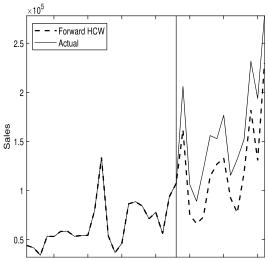

NOTE: figure/graphic rendered as an image from the PDF; its content is not machine-readable text. Caption (if any) follows as the next block.

Figure 1 shows the results for Atlanta. We can clearly see that DID (upper left panel) and SC (lower left panel) do not fit the pretreatment data well, whereas the For ward DID (upper right panel), *SCI* (lower center panel), and Forward HCW (lower right panel) do. Therefore, for Atlanta, DID and SC are not applicable and should be not be used. DID uses an average of all 60 control cit ies’ sales, which has a much flatter trend compared with Atlanta’s steep upward trend during the pretreat ment period. Therefore, the DID counterfactual in the posttreatment period is likely underestimated, which results in overestimating the ATT. SC also does not fit

the Atlanta data well in the pretreatment period. Speci fically, the SC fitted curve is below the actual sales. Because the SC method does not allow an intercept, the SC fitted curve does not have the flexibility to shift upward to match Atlanta’s pretreatment sales. There fore, similar to the DID, the SC method underestimates the counterfactual, which results in overestimating the ATT. By contrast, the Forward DID, *SCI*, and Forward HCW methods fit the in-sample data well in the pre treatment period. However, the Forward HCW method likely overfits the in-sample data because of having to estimate many parameters. In Section 3.2, we compare the out-of-sample performance by method and confirm that indeed Forward HCW performs poorly out-of- sample. Therefore, for Atlanta, DID, SC, and Forward HCW should be not be used, whereas Forward DID and *SCI* remain as applicable methods.

Figure 2 shows that for San Diego, the DID fits the pretreatment data poorly, whereas the other four meth ods (SC, *SCI*, Forward HCW, and Forward DID) fit the in-sample data well. Similar to Atlanta, the DID method

**Figure 1.** Atlanta Sales and Fitted/Predicted Curves by Method

*Notes*. (Upper left panel) DID method. (Upper right panel) Forward DID method. (Lower left panel) SC method. (Lower center panel) SC*I* method. (Lower right panel) Forward HCW method.

Page 7

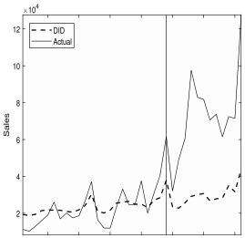

NOTE: figure/graphic rendered as an image from the PDF; its content is not machine-readable text. Caption (if any) follows as the next block.

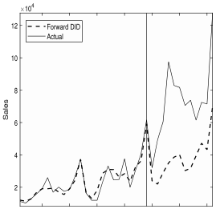

NOTE: figure/graphic rendered as an image from the PDF; its content is not machine-readable text. Caption (if any) follows as the next block.

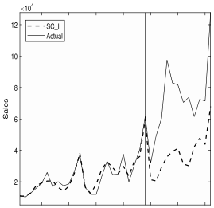

NOTE: figure/graphic rendered as an image from the PDF; its content is not machine-readable text. Caption (if any) follows as the next block.

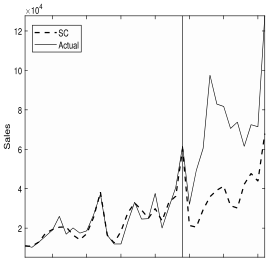

NOTE: figure/graphic rendered as an image from the PDF; its content is not machine-readable text. Caption (if any) follows as the next block.

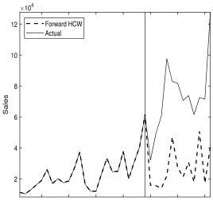

NOTE: figure/graphic rendered as an image from the PDF; its content is not machine-readable text. Caption (if any) follows as the next block.

fits the in-sample data poorly because of its inability to match the upward trends of San Diego’s actual sales. As a result, DID likely underestimates the counterfac tual in the posttreatment and overestimates the ATT. By contrast, the Forward DID, SC, *SCI*, and Forward HCW methods fit the pretreatment data well. Finally, Figure 3 shows that for San Jose, all five methods fit San Jose’s pretreatment sales well. Similar to the Atlanta case, even though the Forward HCW method fits the in-sample data well for San Diego and San Jose, it likely suffers from overfitting because of having to estimate many parameters. In Section 3.2, we compare the out- of-sample performance by method and confirm that indeed Forward HCW performs poorly out-of-sample. Therefore, for San Diego, DID and Forward HCW should not be used, whereas Forward DID, SC, and *SCI* remain as applicable methods. For San Jose, Forward HCW should be excluded, whereas the other four meth ods remain as applicable methods. Although we have discussed which methods should be excluded for each city, for the sake of completeness, we report the ATTs

and confidence intervals (CIs) for all methods in this section and the prediction mean square errors (PMSEs) for all methods in Section 3.2.

Next, we compare the ATT and goodness of fit. Table 1 shows the ATT, ATT percentage, and *R*<sup>2</sup>by method for each of the three cities. Before we discuss the results by city, first note that for the Forward HCW method, the *R*<sup>2</sup>

**Figure 2.** San Diego Sales and Fitted/Predicted Curves by Method

*Notes*. (Upper left panel) DID method. (Upper right panel) Forward DID method. (Lower left panel) SC method. (Lower center panel) SC*I* method. (Lower right panel) Forward HCW method.

Page 8

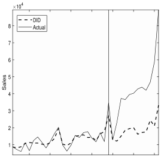

NOTE: figure/graphic rendered as an image from the PDF; its content is not machine-readable text. Caption (if any) follows as the next block.

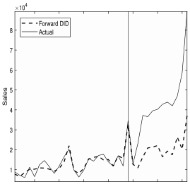

NOTE: figure/graphic rendered as an image from the PDF; its content is not machine-readable text. Caption (if any) follows as the next block.

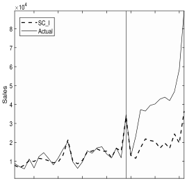

NOTE: figure/graphic rendered as an image from the PDF; its content is not machine-readable text. Caption (if any) follows as the next block.

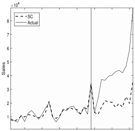

NOTE: figure/graphic rendered as an image from the PDF; its content is not machine-readable text. Caption (if any) follows as the next block.

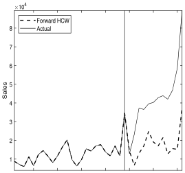

NOTE: figure/graphic rendered as an image from the PDF; its content is not machine-readable text. Caption (if any) follows as the next block.

(DID, SC, *SCI*, and Forward DID) have proper regulariza tion conditions to prevent overfitting. Specifically, the Forward DID has implicit regularization and only esti mates one parameter after identifying a subset of control units; therefore, overfitting is not an issue. Therefore, we exclude Forward HCW because its ATT is not reliable when discussing results in Table 1, which we do so next.

Next, we discuss the ATT, ATT percentage, and *R*<sup>2</sup>

results by city in Table 1. Recall from the discussion of Figure 1 that for Atlanta, DID and SC are not applicable because of their poor in-sample fit and likely over estimate the ATT. This is consistent with the results in

Table 1 that show *R*<sup>2</sup>for DID and SC being very low compared with the other methods and the ATTs from DID and SC being much greater than the ATT from Forward DID and *SCI*. By contrast, Forward DID and *SCI* fit the pretreatment data well and have an *R*<sup>2</sup>of 0.76. Forward DID and *SCI* suggest that opening a store in Atlanta led to an increase in monthly sales of $75,143 (86%). Recall from the discussion of Figure 2 that for San Diego, DID is not applicable because of its poor in-sample fit, and it likely overestimates the ATT. This is consistent with the results in Table 1 that show for San Diego that the SC, *SCI*, and Forward DID methods

**Table 1.** ATT and ATT Percentage by City and Method

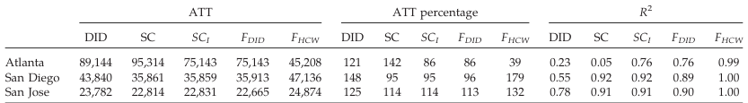

NOTE: complex table shown as an image of the PDF; the text below is a rough machine extraction and may be mis-aligned.

**extracted text (unreliable layout)**

**Figure 3.** San Jose Sales and Fitted/Predicted Curves by Method

*Notes*. (Upper left panel) DID method. (Upper right panel) Forward DID method. (Lower left panel) SC method. (Lower center panel) SC*I* method. (Lower right panel) Forward HCW method.

Page 9

have much larger *R*<sup>2</sup>compared with DID, indicating that they are likely more reliable in this setting and that the ATTs estimated using SC, *SCI*, and Forward DID are smaller than the ATT from DID. Opening a store in San Diego led to a monthly increase in sales in the range of $35,859–$35,913 (95%–96%) according to *SCI*, SC, and Forward DID. Finally, for San Jose, DID, For ward DID, SC, and *SCI* methods have high *R*<sup>2</sup>and simi lar ATTs ranging from $22,665 to $23,782 (we exclude Forward HCW because of overfitting). As we can see from Table 1, in each city, the different methods that are applicable for that city produce similar ATT esti mates, which is a good sanity check.

One major advantage of Forward DID over other flexible alternative estimators to DID is inference the ory that is widely applicable. We develop the inference theory for the Forward DID method, which is applica ble to both stationary and nonstationary data of known and unknown structure. Like DID, Forward DID uses a simple (unweighted) average of control units, which avoids having to estimate a large number of parameters and therefore, leads to simple inference. By contrast, other alternative methods to DID, such as the synthetic control methods (SC and *SCI*) that use a weighted aver aged of control units and the HCW and Forward HCW methods that use a linear combination of control units, do not have inference theory when data are nonstation ary of unknown structure.

We now compute the CIs for the Forward DID and alternative methods (DID, SC, *SCI*, and Forward HCW). Although we compute the confidence intervals for the SC, *SCI*, and Forward HCW methods for the sake of completeness, the confidence intervals for these methods may not be reliable for the following reasons. For the SC and *SCI* methods, there is no inference the ory when the data are nonstationary of unknown structure, which is the setting of this empirical applica tion. To compute the CIs for SC and *SCI*, we apply the subsampling procedure proposed by Li (2020), whose validity requires that the number of pretreatment time periods is much larger than the number of control units and that the data are stationary data or nonsta tionary data of known structure. The Forward HCW method as discussed previously suffers from overfit ting in-sample, which means that the ATT is unreliable.

In addition, the near-perfect in-sample fit results in the estimated error variance being virtually zero and the CI almost shrinking to a single point at <sup>d</sup> *ATTFHCW*. How ever, we cannot interpret these narrow CIs of the Forward HCW as more precise estimates but rather, interpret them as the method breaking down because of overfitting. Therefore, when discussing the CIs and CI width ratios in Table 2, we exclude Forward HCW.

Table 2 shows the 95% CIs and CI width ratios. The CI width ratio is defined as the width of the 95% CI of an alternative method over the width of the 95% CI of the Forward DID method. Therefore, a ratio greater than one indicates that the alternative method has a wider CI than the Forward DID method. There is only one ratio (we exclude Forward HCW) that is smaller than one, which corresponds to Atlanta using SC, but recall that SC is not applicable for Atlanta. All other ratios (excluding Forward HCW) are greater than one, which indicates that Forward DID has narrower confi dence intervals compared with alternative methods.

Finally, notice that for this store opening application, Forward DID and *SCI* are the only methods (of those considered) that are applicable in all three cities, and they perform very similarly in terms of in-sample fit and ATT estimates. Therefore, we take this opportunity to discuss in general when Forward DID is preferable to *SCI* and when it is not. Although Forward DID and *SCI* lead to similar ATTs when they are both applicable, Forward DID is preferable to *SCI* when Forward DID is applicable (i.e., its parallel trends assumption holds) because inference theory is more widely available for Forward DID, which leads to more reliable confidence intervals. Specifically, inference theory is available for Forward DID for stationary and nonstationary data of known and unknown structure, whereas for *SCI*, infer ence theory does not exist when data are nonstationary and the structure of the nonstationary is unknown. By contrast, *SCI* is preferable to Forward DID when For ward DID is not applicable, but *SCI* is still applicable. This can occur because *SCI* is more general than For ward DID as *SCI* allows weights on different control units to be different.

Therefore, in this store opening application, even though Forward DID and *SCI* perform similarly in terms of in-sample fit and ATT estimates, Forward DID

**Table 2.** 95% CI and CI Width Ratio for Each City by Method

|  |  | 95%CI |  | CIwidthratio(overForwardDID) |
| --- | --- | --- | --- | --- |
| Method\city | Atlanta | SanDiego | SanJose | Atlanta SanDiego SanJose |
| DID | [74882 103402] , , , | [38405 49274] , , , | [21875 25690] , , , | 180 216 143 . . . |
| SC | [87264 101423] , , , | [31681 41376] , , , | [18836 25447] , , , | 0858 189 248 . . . |
| SC I | [29314 115262] , , , | [15564 58424] , , , | [6726 36844] , , , | 524 853 113 . . . |
| ForwardDID | [67212 83074] , , , | [33399 38426] , , , | [21331 23998] , , , | 100 100 100 . . . |
| FHCW | [452079 452081] , . , , . | [471359 471360] , . , , . | [248739 248741] , . , , . | 25×106 37×107 97×105 : : : |

NOTE: table converted from PDF layout to HTML text; cell boundaries are reconstructed. See PDF if exact alignment matters.

Page 10

is preferable to *SCI* because the availability of widely applicable inference theory results in more reliable con fidence intervals. In addition, Forward DID’s confi dence intervals are more narrow compared with *SCI*’s confidence intervals, which means we get tighter, more informative bounds and are able to better quantify the uncertainty using Forward DID compared with *SCI*. In the next section, we show that Forward DID also per forms better overall out-of-sample compared with *SCI*.

**3.2. Out-of-Sample Prediction MSE** In this section, we use a backdating exercise to compare the out-of-sample prediction by method. For the back dating exercise, we only use the pretreatment data (*t* ≤ *T*1) and split it into two parts. We pretend that there was an intervention at *T*0 + 1, where *T*0 *< T*1 1, so that the first *T*0 time periods are the new “pretreatment” period and the last *T*1 *T*0 time periods are the new “posttreatment” time period.

We then fit the model using new “pretreatment” data 1 ≤*t* ≤*T*0 and predict counterfactual outcome *y*<sup>0</sup> *tr*,*t* <sup>for</sup> *T*0 + 1 ≤*t* ≤*T*1. Let ˆ*y*<sup>0</sup>

*tr*,*t* <sup>denote the counterfactual esti</sup> mate of *y*<sup>0</sup>

*tr*,*t*<sup>. Because there is no intervention for</sup>*<sup>t</sup>* <sup>≤</sup>*<sup>T</sup>*<sup>1</sup><sup>,</sup> we actually observe *y*<sup>0</sup>

*tr*,*t* <sup>for</sup>*<sup>t</sup>* <sup>≤</sup>*<sup>T</sup>*<sup>1</sup><sup>. Therefore, we can</sup> compute PMSE by

PMSE  1 *T*1 *T*0

X *T*1

**equation / math rendering (image)**

NOTE: contains mathematical notation; text above is the PDF text layer and symbols may be mis-extracted. Image shows the original.

*t**T*0+1

**equation / math rendering (image)**

NOTE: contains mathematical notation; text above is the PDF text layer and symbols may be mis-extracted. Image shows the original.

(*ytr*,*t* ˆ*y*<sup>0</sup>

*tr*,*t*<sup>)</sup><sup>2</sup><sup>,</sup> (3.1)

where ˆ*y*<sup>0</sup>

*tr*,*t* <sup>is one of the five predictors using the DID,</sup> Forward DID, SC, *SCI*, and Forward HCW methods.

Table 3 shows the PMSE for the Forward DID method (divided by 10<sup>7</sup>for readability). To more easily compare Forward DID’s PMSE with alternative meth ods, Table 4 shows the PMSE ratios of a given method (DID, SC, *SCI*, and Forward HCW) over Forward DID. Therefore, PMSE ratios greater than one in Table 4 in dicate that Forward DID performs better out-of-sample. Note that using results from Tables 3 and 4, we can obtain the PMSEs for all methods.

Now, we discuss the results by method starting with Forward HCW. Recall that Forward HCW likely overfits

the pretreatment data because of estimating 22 parameters to fit 23 or 24 data points (pretreatment time periods) and having very high *R*<sup>2</sup>for in-sample fit. Therefore, we expect Forward HCW to perform poorly out-of-sample, which is indeed the case as indicated by large PMSE ratios with one exception for all three cities in Table 4.

Next, we discuss the DID method. When DID fits well in-sample (San Jose) (see Figure 3), it performs the best out-of-sample as indicated by having the smallest PMSE ratios. However, when DID does not fit well in-sample (Atlanta and San Diego) (see Figures 1 and 2), it performs poorly out-of-sample as indicated by large PMSE ratios. Therefore, one takeaway is that DID should be used when it is applicable, and only when DID’s identifying assumption is likely violated should we then consider more flexible alternatives, such as Forward DID and synthetic control methods. Next, we discuss the synthetic control methods without (SC) and with an intercept (*SCI*). When SC does not fit well in-sample (Atlanta) (see Figure 1), it performs poorly out-of-sample as indicated by large PMSE ratios. In this case, adding an intercept to SC improves its perfor mance. For Atlanta, *SCI* performs similarly to the For ward DID as indicated by PMSE ratios equal to one (four of five cases) or close to one (one of five cases). In the two other cases (San Diego and San Jose) where SC fits well in-sample (see Figures 2 and 3), SC and *SCI* per form similarly and are both outperformed by Forward DID.

Finally, we discuss the Forward DID method. From a bird’s-eye view, 43 of 60 PMSE ratios are greater than one, and 4 of 60 PMSE ratios are equal to one, which indi cates that Forward DID performs very well out-of-sample

**Table 3.** *PMSE=*10<sup>7</sup>for the Forward DID Method

| T 0 | Atlanta | SanDiego | SanJose |
| --- | --- | --- | --- |
| 12 | 11126 . | 22248 . | 13842 . |
| 14 | 12147 . | 22658 . | 15641 . |
| 16 | 12541 . | 35044 . | 19491 . |
| 18 | 16099 . | 42309 . | 25349 . |
| 20 | 25857 . | 16783 . | 30483 . |

NOTE: table converted from PDF layout to HTML text; cell boundaries are reconstructed. See PDF if exact alignment matters.

**Table 4.** PMSE Ratio by Method

|  |  |  |  |  |  |  | City |  |  |  |  |
| --- | --- | --- | --- | --- | --- | --- | --- | --- | --- | --- | --- |
|  |  |  | Atlanta |  |  | San | Diego |  |  | SanJose |  |
| T 0/ratio | DID FDID | SC FDID | SCI FDID | FHCW FDID | DID FDID | SC FDID | SCI FDID | FHCW FDID | DID FDID | SC SCI FDID FDID | FHCW FDID |
| 12 | 228 . | 236 . | 0992 . | 0461 . | 314 . | 103 . | 107 . | 399 . | 0358 . | 0817 122 . . | 212 . |
| 14 | 308 . | 785 . | 100 . | 526 . | 259 . | 0977 . | 0987 . | 312 . | 0705 . | 136 141 . . | 354 . |
| 16 | 441 . | 951 . | 100 . | 279 . | 316 . | 141 . | 116 . | 950 . | 0468 . | 147 139 . . | 325 . |
| 18 | 226 . | 757 . | 100 . | 390 . | 259 . | 139 . | 111 . | 911 . | 0428 . | 117 128 . . | 482 . |
| 20 | 160 . | 550 . | 100 . | 160 . | 254 . | 0798 . | 214 . | 366 . | 0453 . | 0740 0975 . . | 194 . |

NOTE: table converted from PDF layout to HTML text; cell boundaries are reconstructed. See PDF if exact alignment matters.

*Note*. FDID, forward difference-in-differences.

Page 11

relative to other methods. Delving deeper into the 13 cases where Forward DID is outperformed, 5 of the cases are when DID performs best for San Jose. In this case, For ward DID comes in second after DID and thus, performs best among the alternatives to DID. Of the remaining eight cases where Forward DID is outperformed, For ward DID still outperforms alternative methods overall. In other words, for a given column that contains one of the remaining eight cases (where the ratio is less than one), at least three or four of the five scenarios with differ ent *T*0 favor Forward DID. In summary, when DID is applicable, it should be used as it outperforms alternative flexible methods. However, Forward DID performs best out of the alternative flexible methods. When DID is not applicable, Forward DID performs favorably in the vast majority of cases in out-of-sample prediction among alter native methods.

In summary, this store entry setting is a good place to use Forward DID (relative to other methods) because Forward DID is applicable in all three cities (i.e., paral lel pretrends assumption holds), it has a simple and widely applicable inference theory to calculate confi dence intervals, it does not suffer from overfitting, and it performs well out-of-sample.

**4. Conclusion** The difference-in-differences method is the most popu lar quasiexperimental approach for estimating causal effects. It is simple, easy to implement, and applicable for any number of treatment and control units and for any number of pretreatment and posttreatment time periods. However, its identifying parallel trends assumption may be violated in quasiexperimental data where the treat ment and control units are heterogeneous. There have been many recent developments expanding the causal inference tool kit to include more flexible estimators, such as the synthetic control method (with and without an intercept), the HCW method, and the Forward HCW method. However, these flexible methods also have limitations. First, their inference theory does not exist for nonstationary data of unknown structure. Second, the (Forward) HCW is not feasible when the number of (selected) control units is greater than the number of pretreatment time periods and likely suffers from overfitting.

We propose a simple Forward DID method that takes advantage of the forward selection algorithm to flexibly select a relevant subset of control units. The Forward DID has several advantages. First, it can be widely applied and suitable even when DID is too restrictive. Second, Forward DID can accommodate any number of control units. Third, there are no overfitting concerns because Forward DID only needs to estimate one param eter after identifying a relevant subset of control units. Fourth, Forward DID has computational advantages over

algorithms that consider all possible subsets of control units. Fifth, we develop the inference theory that is appli cable to both stationary and nonstationary data of known and unknown structures. Finally, we establish the consis tency of the Forward DID method. The inference theory and the consistency results are the main theoretical results of the paper. To facilitate ease of use, we provide a practitioner’s guide outlining steps of how to use For ward DID to estimate the ATT and conduct inference in the appendix. Although we only consider estimation of ATT based on treatment and control units’ outcome vari ables, future research could consider adding relevant covariates to the Forward DID method.

As with any methodology, it is also important to understand its boundary conditions. The Forward DID method should not be used when its identifying paral lel trends assumption is violated. An example of this scenario would be when the intercept-adjusted treat ment is outside the range of the control units (e.g., the treatment unit’s outcome has an upward trend that is steeper than that of all the control units’ outcomes). In such a case, it is not possible to find a subset of control units whose average traces the treatment unit well in the pretreatment period.

Fortunately, because of the flexibility of the forward selection algorithm, there are many empirical marketing and business settings in which the Forward DID is appli cable. The Forward DID belongs to a class of flexible alternatives to the DID method. These flexible alterna tive methods should be used when DID is not applicable because of its identifying parallel trends assumption being violated. Compared with other flexible alterna tives to the DID method (e.g., SC with or without an intercept, HCW, and Forward HCW), the Forward DID

Page 12

method is especially useful to researchers in settings where inference is important and data are nonstationary of unknown structure. Whereas the synthetic control method (with and without an intercept), the HCW method, and the Forward HCW method lack widely applicable inference theory, the Forward DID method has a simple normal inference theory, which we derive, that is widely applicable to both stationary and nonsta tionary data of known and unknown structures. The Forward DID method is a powerful causal inference tool that complements existing methods well and expands the set of causal research questions that researchers can answer.

**Acknowledgments** The author is grateful for insightful comments from the editor, the associate editor, and two reviewers that greatly improved the paper. The author also thanks Unnati Narang, Garrett P. Sonnier, Raji Srinivasan, Ioannis Stamatopoulos, and Chris tophe Van den Bulte; the participants of the 2022 Artificial Intelligence, Machine Learning and Business Analytics Con ference, the 2023 Cornell Young Scholar Camp, and the McCombs School of Business Research Colloquium; and the marketing seminar participants at the University of California Riverside School of Business, the University of Florida War rington College of Business, and Carnegie Melon University Tepper School of Business for valuable comments. The author certifies that there are no affiliations with or involvement in any organization or entity with any financial interest or nonfi nancial interest in the subject matter or materials discussed in this manuscript.

**Appendix. A Practitioner’s Guide** In this appendix, we outline the steps of using the Forward DID method to estimate ATT and conduct inference.

Step 1. Use the Forward DID forward selection algorithm described in Section 2.2 to select a subset of controls that has the largest *R*<sup>2</sup>. Let <sup>c</sup> N *co* denote the selected subset. Step 2. Compute the counterfactual outcomes using (2.5) (i.e., ˆ*y*<sup>0</sup>

**equation / math rendering (image)**

NOTE: contains mathematical notation; text above is the PDF text layer and symbols may be mis-extracted. Image shows the original.

**equation / math rendering (image)**

NOTE: contains mathematical notation; text above is the PDF text layer and symbols may be mis-extracted. Image shows the original.

*i*∈<sup>ˆ</sup>N *co<sup>y</sup><sup>it</sup>*<sup>, and</sup><sup>b</sup>*<sup>N</sup><sup>co</sup>*<sup>is the number of control units in</sup><sup>c</sup> N *co*). Step 3. Plot ˆ*y*<sup>0</sup>

*tr*,*t* <sup>and</sup>*<sup>y</sup><sup>tr</sup>*<sup>,</sup>*<sup>t</sup>*<sup>for</sup>*<sup>t</sup>*<sup></sup><sup>1,</sup>*<sup>:::</sup>*<sup>,</sup>*<sup>T</sup>*<sup>1</sup><sup>, and check</sup> whether parallel pretrends between ˆ*y*<sup>0</sup>

*tr*,*t* <sup>and</sup>*<sup>y</sup><sup>tr</sup>*<sup>,</sup>*<sup>t</sup>*<sup>hold (i.e.,</sup> whether ˆ*y*<sup>0</sup>

*tr*,*t* <sup>traces</sup>*<sup>y</sup><sup>tr</sup>*<sup>,</sup>*<sup>t</sup>*<sup>well in the pretreatment period).</sup> Visual inspection is an effective way of checking this.

Move to Step 4 if the parallel pretrends hold. Otherwise, do not use the Forward DID method, and consider other methods whose parallel pretrends hold.

Step 4. Estimate *ATT* by <sup>d</sup> *ATT*  <sup>1</sup>

**equation / math rendering (image)**

NOTE: contains mathematical notation; text above is the PDF text layer and symbols may be mis-extracted. Image shows the original.

*t**T*1+1<sup>(</sup>*<sup>y</sup><sup>tr</sup>*<sup>,</sup>*<sup>t</sup>* <sup>ˆ</sup>*<sup>y</sup>*<sup>0</sup>

*tr*,*t*<sup>)</sup><sup>,</sup> where ˆ*y*<sup>0</sup>

*tr*,*t* <sup>is computed in Step 2.</sup> Step 5. Compute the (1 α) confidence interval of ATT by

**equation / math rendering (image)**

NOTE: contains mathematical notation; text above is the PDF text layer and symbols may be mis-extracted. Image shows the original.

**equation / math rendering (image)**

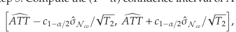

NOTE: contains mathematical notation; text above is the PDF text layer and symbols may be mis-extracted. Image shows the original.

where *c*α is the upper αth quantile of a standard normal ran dom variable. For example, the 95% confidence interval of ATT is given by

**equation / math rendering (image)**

NOTE: contains mathematical notation; text above is the PDF text layer and symbols may be mis-extracted. Image shows the original.

**equation / math rendering (image)**

NOTE: contains mathematical notation; text above is the PDF text layer and symbols may be mis-extracted. Image shows the original.

**equation / math rendering (image)**

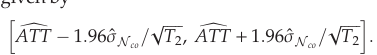

NOTE: contains mathematical notation; text above is the PDF text layer and symbols may be mis-extracted. Image shows the original.

**equation / math rendering (image)**

NOTE: contains mathematical notation; text above is the PDF text layer and symbols may be mis-extracted. Image shows the original.

#### **Endnotes**

**1** MATLAB and R code implementing Forward DID using a publicly available data set can be found on the *Marketing Science* website (fol lowing the journal’s replication policy) and on the author’s website.

**2** In mathematical terminology, *Nco* is the cardinality of the set N *co*.

**3** Both α and *vt* also depend on N *co*. However, for notational sim plicity, we often do not include N *co* as a subscript for α and *vt*.

**4** We do not consider the HCW method in simulations because it is not feasible when the number of control units is larger than the number of pretreatment time periods.

**References** Abadie A (2021) Using synthetic controls: Feasibility, data require

ments, and methodological aspects. *J. Econom. Literature* 59(2): 391–425. Abadie A, Gardeazabal J (2003) The economic costs of conflict: A

case study of the Basque Country. *Amer. Econom. Rev.* 93(1): 113–132. Abadie A, L’hour J (2021) A penalized synthetic control estimator for

disaggregated data. *J. Amer. Statist. Assoc.* 116(536):1817–1834. Abadie A, Diamond A, Hainmueller J (2010) Synthetic control methods

for comparative case studies: Estimating the effect of California’s tobacco control program. *J. Amer. Statist. Assoc.* 105(490):493–505. Ando T, Bai J (2016) Panel data models with grouped factor struc

ture under unknown group membership. *J. Appl. Econometrics* 31(1):163–191. Bai J (2003) Inferential theory for factor models of large dimensions.

*Econometrica* 71(1):135–171. Bai J, Ng S (2021) Matrix completion, counterfactuals, and factor analysis

of missing data. *J. Amer. Statist. Assoc.* 116(536):1746–1763. Bell DR, Gallino S, Moreno A (2018) Offline showrooms in omni

channel retail: Demand and operational benefits. *Management Sci.* 64(4):1629–1651. Berman R, Israeli A (2022) The value of descriptive analytics: Evi

dence from online retailers. *Marketing Sci.* 41(6):1074–1096. Bonhomme S, Manresa E (2015) Grouped patterns of heterogeneity

in panel data. *Econometrica* 83(3):1147–1184. Busse M, Silva-Risso J, Zettelmeyer F (2006) $1,000 cash back: The

pass-through of auto manufacturer promotions. *Amer. Econom. Rev.* 96(4):1253–1270. Calzada J, Gil R (2020) What do news aggregators do? Evidence from

Google News in Spain and Germany. *Marketing Sci.* 39(1):134–167. Chesnes M, Dai W, Zhe Jin G (2017) Banning foreign pharmacies

from sponsored search: The online consumer response. *Market ing Sci.* 36(6):879–907. Doudchenko N, Imbens GW (2016) Balancing, regression, difference-

in-differences and synthetic control methods: A synthesis. NBER Working Paper No. 22791, National Bureau of Economic Research, Cambridge, MA. Goldfarb A, Tucker CE (2011) Privacy regulation and online adver

tising. *Management Sci.* 57(1):57–71. Guo T, Sriram S, Manchanda P (2020) “Let the sunshine in”: The

impact of industry payment disclosure on physician prescrip tion behavior. *Marketing Sci.* 39(3):516–539. Hsiao C, Ching SH, Wan SK (2012) A panel data approach for pro

gram evaluation: Measuring the benefits of political and eco nomic integration of Hong Kong with mainland China. *J. Appl. Econometrics* 27(5):705–740. Johnson GA, Shriver SK, Du S (2020) Consumer privacy choice in

online advertising: Who opts out and at what cost to industry? *Marketing Sci.* 39(1):33–51. Li KT (2020) Statistical inference for average treatment effects estimated

by synthetic control methods. *J. Amer. Statist. Assoc.* 115(532): 2068–2083.

Page 13

Li KT, Sonnier GP (2023) Statistical inference for the factor model

approach to estimate causal effects in quasi-experimental set tings. *J. Marketing Res.* 60(3):449–472. Li KT, Van den Bulte C (2023) Augmented difference-in-differences.

*Marketing Sci.* 42(4):746–767. Liaukonyte J, Teixeira T, Wilbur KC (2015) Television advertising

and online shopping. *Marketing Sci.* 34(3):311–330. Mantin B, Rubin E (2016) Fare prediction websites and transaction

prices: Empirical evidence from the airline industry. *Marketing Sci.* 35(4):640–655. Puranam D, Narayan V, Kadiyali V (2017) The effect of calorie posting

regulation on consumer opinion: A flexible latent Dirichlet alloca tion model with informative priors. *Marketing Sci.* 36(5):726–746. Seiler S, Tuchman A, Yao S (2021) The impact of soda taxes: Pass-

through, tax avoidance, and nutritional effects. *J. Marketing Res.* 58(1):22–49.

Shi Z, Huang J (2023) Forward-selected panel data approach for

program evaluation. *J. Econometrics* 234(2):512–535. Su L, Shi Z, Phillips PC (2016) Identifying latent structures in panel

data. *Econometrica* 84(6):2215–2264. Tirunillai S, Tellis GJ (2017) Does offline TV advertising affect online

chatter? Quasi-experimental analysis using synthetic control. *Marketing Sci.* 36(6):862–878. Todri V (2022) Frontiers: The impact of ad-blockers on online con

sumer behavior. *Marketing Sci.* 41(1):7–18. Wang Y, Qin MS, Luo X, Kou Y (2022) Frontiers: How support for Black

Lives Matter impacts consumer responses on social media. *Market ing Sci.* 41(6):1029–1044. Xu Y (2017) Generalized synthetic control method: Causal in

ference with interactive fixed effects models. *Political Anal*. 25(1):57–76.

Page 14